# Model Selection

László Kovács

02/05/2025

## 1. Industry Accounting Data

The file called industry.csv which contains data of 479 industries (e.g. mining, wood processing, information technology services, etc.) of the Hungarian economy in 17 variables (columns) for a given accounting year.

- Earnings: earnings (billion HUF)
- NrComps: number of companies in the industry (number of)
- Prof: number of companies in the industry that are profitable (number of)
- Unprof: number of unprofitable companies in the industry (number of)
- Workers: number of workers in the industry (number of)
- FAssets: value of fixed assets (billion HUF)
- CAssets: value of current assets (billion HUF)
- FCAssets: value of fixed current assets (billion HUF)
- Assets: value of assets (billion HUF)
- Equity: value of equity (billion HUF)
- Liab: value of liabilities (billion HUF)
- LTLiab: value of long-term liabilities (billion HUF)
- STLiab: value of short-term liabilities (billion HUF)
- SUBLiab: value of liabilities subordinated (billion HUF)
- MatExp: value of material expenses (billion HUF)
- PersExp: value of personnel expenses (billion HUF)
- Dep: value of depreciation (billion HUF)

Let’s set the `working directory` appropriately and import the file! Luckily it’s a well behaving *.csv* so we can use `read.csv`:

```r
ind <- read.csv("industry.csv")
str(ind)
```

```
## 'data.frame':    479 obs. of  17 variables:
##  $ Earnings: num  9.047 1.553 1.967 0.516 -0.027 ...
##  $ NrComps : int  2598 605 644 456 162 338 559 187 388 1541 ...
##  $ Prof    : int  1374 304 315 258 86 158 335 96 164 840 ...
##  $ Unprof  : int  1224 301 329 198 76 180 224 91 224 701 ...
##  $ Workers : num  36.68 5.08 3 13.11 0.51 ...
##  $ FAssets : num  238.85 31.79 44.74 86.56 6.27 ...
##  $ CAssets : num  221.65 21.06 20.08 64.78 3.73 ...
##  $ FCAssets: num  460.49 52.84 64.83 151.34 9.99 ...
##  $ Assets  : num  469.2 53.3 65.2 152.5 10.3 ...
##  $ Equity  : num  237.61 27.54 30.36 80.48 3.33 ...
##  $ Liab    : num  222.71 24.34 31.81 68.52 6.66 ...
##  $ LTLiab  : num  87.33 9.41 12.38 27.91 3.15 ...
##  $ STLiab  : num  131.38 13.96 17.56 39.15 2.57 ...
##  $ SUBLiab : num  4.007 0.976 1.871 1.468 0.941 ...
##  $ MatExp  : num  303.9 35.9 20.6 92.7 5.9 ...
##  $ PersExp : num  58.564 6.822 3.83 21.744 0.486 ...
##  $ Dep     : num  26.011 3.052 2.22 8.622 0.529 ...
```

Everything looks fine in the `data frame`. Also, each variable is numeric data, so we don’t have to change anything here either.

Let’s run an OLS regression where earnings are explained by 12 variables:

```r
model_1 <- lm(Earnings ~ Prof + Unprof + Workers + FAssets + CAssets +
                Equity + LTLiab + STLiab + SUBLiab + MatExp +
                PersExp + Dep, data = ind)
summary(model_1)
```

```
##
## Call:
## lm(formula = Earnings ~ Prof + Unprof + Workers + FAssets + CAssets +
##     Equity + LTLiab + STLiab + SUBLiab + MatExp + PersExp + Dep,
##     data = ind)
##
## Residuals:
##     Min      1Q  Median      3Q     Max
## -39.368  -0.944  -0.075   0.680  83.287
##
## Coefficients:
##              Estimate Std. Error t value Pr(>|t|)
## (Intercept)  0.067752   0.381429   0.178 0.859093
## Prof         0.003096   0.002168   1.428 0.153920
## Unprof       0.002824   0.002492   1.133 0.257644
## Workers     -0.614606   0.142640  -4.309 2.00e-05 ***
## FAssets     -0.016283   0.009457  -1.722 0.085769 .
## CAssets      0.056677   0.014335   3.954 8.89e-05 ***
## Equity       0.015730   0.010251   1.535 0.125570
## LTLiab      -0.044290   0.012016  -3.686 0.000255 ***
## STLiab      -0.085435   0.015429  -5.537 5.14e-08 ***
## SUBLiab      0.141196   0.223540   0.632 0.527935
## MatExp       0.022815   0.003152   7.239 1.87e-12 ***
## PersExp      0.102731   0.082943   1.239 0.216127
## Dep          1.056909   0.080101  13.195  < 2e-16 ***
## ---
## Signif. codes:  0 '***' 0.001 '**' 0.01 '*' 0.05 '.' 0.1 ' ' 1
##
## Residual standard error: 7.098 on 466 degrees of freedom
## Multiple R-squared:  0.8735, Adjusted R-squared:  0.8703
## F-statistic: 268.2 on 12 and 466 DF,  p-value: < 2.2e-16
```

The model looks very good, with an explanatory power of $87.35\%$, the model is significant on all usual $\alpha$ significance levels (global F-test). **Note**: range of usual significance levels: $1\% \leq \alpha \leq 10\%$

Partial t-tests indicate that the non-significant explanatory variables at $\alpha=5\%$ are **Prof**, **Unprof**, **FAssets**, **Equity**, **SUBLiab** and **PersExp**. If these variables are not related to the earnings of the industries, they should be dropped from the model:

```r
model_2 <- lm(Earnings ~ Workers + CAssets + LTLiab +
                STLiab + MatExp + Dep, data = ind)
summary(model_2)
```

```
##
## Call:
## lm(formula = Earnings ~ Workers + CAssets + LTLiab + STLiab +
##     MatExp + Dep, data = ind)
##
## Residuals:
##     Min      1Q  Median      3Q     Max
## -41.648  -0.679  -0.336   0.550  83.252
##
## Coefficients:
##              Estimate Std. Error t value Pr(>|t|)
## (Intercept)  0.465328   0.394592   1.179    0.239
## Workers     -0.274589   0.058308  -4.709 3.27e-06 ***
## CAssets      0.055343   0.007066   7.832 3.20e-14 ***
## LTLiab      -0.042174   0.007161  -5.890 7.36e-09 ***
## STLiab      -0.084519   0.006205 -13.622  < 2e-16 ***
## MatExp       0.028269   0.003086   9.159  < 2e-16 ***
## Dep          1.033927   0.046118  22.419  < 2e-16 ***
## ---
## Signif. codes:  0 '***' 0.001 '**' 0.01 '*' 0.05 '.' 0.1 ' ' 1
##
## Residual standard error: 7.466 on 472 degrees of freedom
## Multiple R-squared:  0.8583, Adjusted R-squared:  0.8565
## F-statistic: 476.5 on 6 and 472 DF,  p-value: < 2.2e-16
```

OHHH! The explanatory power of our model has degraded to $85.83\%$! But the variables we dropped didn’t look significant! The lowest t-test p-value is $8.58\%$ (**FAssets**)! Why is $R^2$ decreasing?

## 2. Adjusted $R^2$ and Information Criteria

Unfortunately, the good old $R^2$ will never improve if we drop an explanatory variable from the model. No matter how useless.

Why is that? First, $R^2=1-\frac{SSE}{SST}$ and so by minimizing $SSE$ we get the coefficients $\beta_j$. We choose their values in such a way that the OBSERVED values of $y$ we have choose fit the regression estimate $\hat{y}$ as well as possible!

And this fit is certainly NOT worsened by the inclusion of an additional explanatory variable, no matter how irrelevant to $y$. After all, there is one more $\beta_j$ to minimize the model error ($SSE$). But if we step out into the world beyond our observations (universe/population), the $\hat{y}$ estimates are already spoiled by these irrelevant explanatory variables in the model. This is the phenomenon of **overfitting**!

Let’s take a look in the below picture:

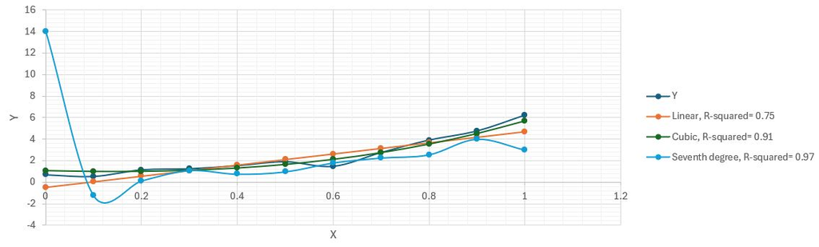

Behind the fitted curves there are the following equations:

- Linear = $5.13x-0.46$
- Cubic = $2.48x^3+3.17x^2−1.06x +1.08$
- Seventh degree (septic) = $−7426x^7+28047x^6−42886x^5+33991x^4−14814x^3+3457x^2−380x+14$

From the figure we can see that the most realistic fit is the *cubic* curve using 3 explanatory variables ($x^3, x^2, x$). But $R^2$ still prefers the seventh degree option using the most explanatory variables because of **overfitting**!

To avoid this we introduce the adjusted $R^2$ indicator:

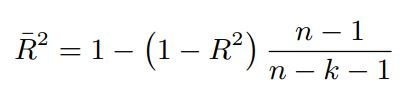

The point of the correction formula is that this indicator can also decrease if irrelevant (highly non-significant) explanatory variables are included in the model. Therefore, the formula includes the number of explanatory variables $k$ in addition to the number of observations $n$.

As we can see, in our previous example $\bar{R}^2$ already prefers the third-degree model, quite correctly!

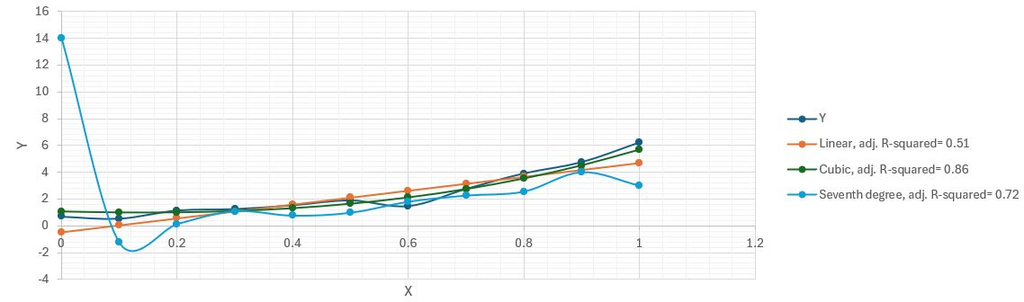

If we save the result of the `summary` functions of R in a separate object, we can collect the $\bar{R}^2$ of our two models under each other. By default, you can read them from the `summary` function’s result table, but there’s a lot more in there, so it’s easy to get lost in the details. [Simplicity](https://hvg.hu/itthon/20111226_errol_szolt_2011) is better. :)

```r
model_1_sum <- summary(model_1)
model_1_sum$adj.r.squared
```

```
## [1] 0.8702603
```

```r
model_2_sum <- summary(model_2)
model_2_sum$adj.r.squared
```

```
## [1] 0.8564952
```

Oof! Even $\bar{R}^2$ indicates that **model_1** is superior! :(

We have two options.

1. We resign ourselves to our unlucky fate and accept that it was really not a good idea to leave out all of the non-significant variables at 5% significance level from **model_1**.
2. We dig further, and find that many statisticians think **that $\bar{R}^2$ doesn’t penalize unnecessary explanatory variables hard enough**!

Let’s move on with the second train of thought. Since $\bar{R}^2$ does not penalize unnecessary explanatory variables strictly enough, 3 metrics for measuring the explanatory power of models have been invented that do so. These are the so-called **information criteria**.

- Akaike Information Criterion: $AIC=\frac{SSE}{n}e^{2p/n}$
- Hannan-Quinn Information Criterion: $HQC=\frac{SSE}{n}(\ln{n})^{2p/n}$
- Bayes-Schwarz Information Criterion: $BIC=\frac{SSE}{n}n^{p/n}$

There are 4 things to know regarding these formulas.

1. $p$ here means not only the number of explanatory variables in the model, but also the $\beta_0$, the intercept term! So, there is **$p$ = number of estimated parameters ($\beta$-s)**!
2. $IC$s by themselves do not show anything useful. They cannot be understood as a % explanatory power like $\bar{R}^2$!
3. Since they come from $SSE$ (i.e. the total *error* of the model) and then stack some $k$-dependent penalty on top of it, they are good for the fact that if you calculate them for 2 models, you can consider the model with the smaller $IC$ to be better!
4. The strictness of the penalizing effect of unnecessary variables gives us the following hierarchical order: $AIC<HQC<BIC$. So, an extra explanatory variable in the model is best tolerated by $AIC$. The least tolerant is $BIC$ for the inclusion of an extra explanatory variable.

Let’s calculate for example $AIC$ for **model_1**:

```r
# most important data for model_1
n <- nrow(ind)
p <- length(coef(model_1)) # this way intercept will be included
SSE <- deviance(model_1) # SSE with built-in function

AIC_1 <- SSE/n*exp(2*p/n) # exp is the function for e to the power of something
AIC_1
```

```
## [1] 51.75455
```

This is very cute, but in practice we prefer to use the built-in functions of R!  
Before we get into this, an **important** piece of information! There are several versions of each $IC$. E.g. you don’t necessarily have to divide them by $n$, and you can take the logarithm of them. Then, for example, $AIC=\ln{SSE}+2k$ and $BIC=\ln{SSE}+k\ln{n}$. **So don’t be upset if some built-in function in R computes $IC$ differently than the formula given in the formula collection!** The point is to **keep the indicators consistent with each other** so that the relation $AIC<HQC<BIC$ holds! The functions in the lecture note behave like this, so they’ll be good for us! :)

```r
AIC(model_1,model_2)
```

|  | df | AIC |
| --- | --- | --- |
| model_1 | 14 | 3251.723 |
| model_2 | 8 | 3294.152 |

```r
BIC(model_1,model_2)
```

|  | df | BIC |
| --- | --- | --- |
| model_1 | 14 | 3310.126 |
| model_2 | 8 | 3327.526 |

We can see that for both $IC$ **model_1** is preferred. Even by the strictest $BIC$ it was stupid to omit non-significant variables from **model_1**.

Maybe we can look at $HQC$, but he will say the same thing, as the two extreme $IC$ give the same result.  
Plus, $HQC$ is not in R by default, nor is there a convenient package for it that would compute it to be computationally compatible with the base R `AIC` and `BIC` functions. But if someone finds something for it, don’t hesitate to let me know! :)

## 3. The Wald-test

Well, based on the adjusted $R^2$ and the $IC$, we can clearly say that **model_1** using more variables has better explanatory power in the out-of-sample world than the variable-selected **model_2**.

But if we want to find out about the explanatory power of the models out of sample, i.e. measured in a population, it would be more legitimate to do so using a hypothesis test!  
This is our idea. Okay-okay, **if I leave out explanatory variables from the model, then the regular $R^2$ decrease is inevitable, but the question is, is this decrease significant?** Is it due to sampling error? If so, then the variables can be dropped. If not, then we should keep them. Well, **that’s what the Wald test is for**!

So let’s see the steps of hypothesis testing!

1. **Hypotheses**
- In the **null hypothesis** of the Wald test, we assume that the beta of **an arbitrary number of variable (say $m$ number of variables) in our regression model in the out-of-sample world is 0**.
- We want to test whether $m$ of the explanatory variables can be omitted from the model collectively because each of them has an effect of 0 on the outcome variable. Here $1 ≤ m ≤ k$, where $k$ is the number of explanatory variables in the model.
  - Thus $H_0:\beta_{q+1}=\beta_{q+2}=...=\beta_{q+m}=0$
- Where $q$ is the number of variables whose beta is not assumed to be 0 (which we do not want to leave out of the model) –> so: $q+m=k$
- **An alternative hypothesis**, analogous to the ANOVA (global F-test) test, is that **there is at least one beta of the $m$ variables to be discarded that is not 0**.
2. **Test Statistic**
- The principle is to re-estimate the model without the $m$ explanatory variables to be removed, and see how much $R^2$ has decreased.
  - The formula for the Test Statistic is $\frac{(R^2_U-R^2_R)/m}{(1-R^2_U)/(n-q-m-1)}$
    - $R^2_R$ is the $R^2$ of the restricted model with only $q$ explanatory variables
    - $R^2_U$: the $R^2$ value of the unrestricted model with all $q+m=k$ explanatory variables
3. **The p-value**
- For a true $H_0$, the distribution of our sample function from many samples will be an **F-distribution** with $m$ and $n-q-m-1 = n-k-1$ degrees of freedom.
- The key thing is that you can calculate a p-value from it just like from the F-distribution of the global F-sample:

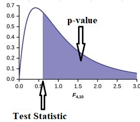

- Decide, knowing the p-value, the same way - using significance levels - as before!

#### SPECIAL CASES

It is important to see that the Wald test includes all of our regression hypothesis tests so far (t-test for each variable and global F-test)!

### 3.1. Wald test in R

Let’s first do a Wald test manually in R between **model_1** and **model_2**!

```r
m <- length(coef(model_1))-length(coef(model_2)) # # of dropped variables
q <- length(coef(model_2)) # # of variables left in the model +1 because of the constant
n <- nrow(ind)

Rsq_1 <- model_1_sum$r.squared #Unrestricted

Rsq_2 <- model_2_sum$r.squared #Restricted

TestFunction <- ((Rsq_1-Rsq_2)/m)/((1-Rsq_1)/(n-q-m))

# p-value
1-pf(TestFunction,m,n-q-m)
```

```
## [1] 1.080767e-09
```

Based on this, we reject $H_0$ for all the common $\alpha$ –> There is at least one explanatory variable which it did not make sense to omit from the model!

We are not completely masochistic though, we can perform this test with a built-in R function:

```r
anova(model_1, model_2)
```

|  | Res.Df | RSS | Df | Sum of Sq | F | Pr(>F) |
| --- | --- | --- | --- | --- | --- | --- |
| 1 | 466 | 23480.68 | NA | NA | NA | NA |
| 2 | 472 | 26306.33 | -6 | -2825.65 | 9.346356 | 1.080767e-09 |

Unfortunately, we have the exact same p-value, so we still adopt $H_1$ as the realistic hypothesis for all common $\alpha$. :(

## 4. The LM-test

The same $H_0$ that is tested in the Wald test can also be tested in the so-called LM test.

- So, $H_0$ is still that **the beta of any arbitrary number of variables (say $m$ of them) in the out-of-sample world is 0**.
- And $H_1$, on the other hand, is that **there is at least one beta of the $m$ variables to be discarded that is not 0**.

But the Test Statistic here takes a different form: $(n-q-m-1)\frac{R^2_U-R^2_R}{1-R^2_R}$

This Test Statistic for true $H_0$ has a distribution $\chi^2(m)$ for many many samples.

The p-value is computed in a right-sided way (i.e. as a probability of falling towards the Test Statistic, similarly to the Wald test) from the distribution valid for $H_0$, as in the best case the $R^2$ of the two models are not different, from which only positive deviations are possible (because of the basic behaviour of $R^2$, it is always $R^2_U \geq R^2_R$).

We can calculate all this in R in like this:

```r
m <- length(coef(model_1))-length(coef(model_2)) # # of dropped variables
q <- length(coef(model_2)) # # of variables left in the model +1 because of the constant
n <- nrow(ind)

Rsq_1 <- model_1_sum$r.squared #Unrestricted

Rsq_2 <- model_2_sum$r.squared #Restricted

TestFunction <- (n-q-m)*(Rsq_1-Rsq_2)/(1-Rsq_2)

# p-value
1-pchisq(TestFunction,m)
```

```
## [1] 4.584066e-09
```

Here again, for all the common $\alpha$ levels, we will reject $H_0$. :( It still doesn’t seem to be a good idea to omit non-significant variables from **model_1**!

For the LM test, we don’t look at a built-in R function (I don’t think there is one), since by default this test is not very useful, because it typically pulls towards accepting $H_0$. So, it generally prefers the restricted model.

That being said, even this test doesn’t say that **model_2** is better than **model_1**, so let’s dismiss this **model_2** and try to narrow the number of explanatory variables in **model_1** in a different way!

## 5. A Model Selection “Trick”

We have already seen that **model_2** will not be better than **model_1** from any point of view.

But let’s take a closer look at **model_1**’s regression output and use our brains!

```r
model_1 <- lm(Earnings ~ Prof + Unprof + Workers + FAssets + CAssets +
                Equity + LTLiab + STLiab + SUBLiab + MatExp +
                PersExp + Dep, data = ind)
summary(model_1)
```

```
##
## Call:
## lm(formula = Earnings ~ Prof + Unprof + Workers + FAssets + CAssets +
##     Equity + LTLiab + STLiab + SUBLiab + MatExp + PersExp + Dep,
##     data = ind)
##
## Residuals:
##     Min      1Q  Median      3Q     Max
## -39.368  -0.944  -0.075   0.680  83.287
##
## Coefficients:
##              Estimate Std. Error t value Pr(>|t|)
## (Intercept)  0.067752   0.381429   0.178 0.859093
## Prof         0.003096   0.002168   1.428 0.153920
## Unprof       0.002824   0.002492   1.133 0.257644
## Workers     -0.614606   0.142640  -4.309 2.00e-05 ***
## FAssets     -0.016283   0.009457  -1.722 0.085769 .
## CAssets      0.056677   0.014335   3.954 8.89e-05 ***
## Equity       0.015730   0.010251   1.535 0.125570
## LTLiab      -0.044290   0.012016  -3.686 0.000255 ***
## STLiab      -0.085435   0.015429  -5.537 5.14e-08 ***
## SUBLiab      0.141196   0.223540   0.632 0.527935
## MatExp       0.022815   0.003152   7.239 1.87e-12 ***
## PersExp      0.102731   0.082943   1.239 0.216127
## Dep          1.056909   0.080101  13.195  < 2e-16 ***
## ---
## Signif. codes:  0 '***' 0.001 '**' 0.01 '*' 0.05 '.' 0.1 ' ' 1
##
## Residual standard error: 7.098 on 466 degrees of freedom
## Multiple R-squared:  0.8735, Adjusted R-squared:  0.8703
## F-statistic: 268.2 on 12 and 466 DF,  p-value: < 2.2e-16
```

We can logically combine some of the explanatory variables that are not significant in any standard $\alpha$ with other variables in the data table.

- $Prof+Unprof=NrComps$
- $LTLiab+STLiab+SUBLiab=Liab$

Let’s create **model_3** using the above ideas:

```r
model_3 <- lm(Earnings ~ NrComps + Workers + FAssets + CAssets +
                Equity + Liab + MatExp + PersExp + Dep, data = ind)
summary(model_3)
```

```
##
## Call:
## lm(formula = Earnings ~ NrComps + Workers + FAssets + CAssets +
##     Equity + Liab + MatExp + PersExp + Dep, data = ind)
##
## Residuals:
##     Min      1Q  Median      3Q     Max
## -47.184  -0.904  -0.073   0.710  83.233
##
## Coefficients:
##               Estimate Std. Error t value Pr(>|t|)
## (Intercept)  0.0675580  0.3825751   0.177  0.85991
## NrComps      0.0031037  0.0004602   6.745 4.53e-11 ***
## Workers     -0.5995231  0.1385072  -4.328 1.84e-05 ***
## FAssets     -0.0131503  0.0093240  -1.410  0.15909
## CAssets      0.0341491  0.0111282   3.069  0.00227 **
## Equity       0.0251122  0.0091581   2.742  0.00634 **
## Liab        -0.0571398  0.0104214  -5.483 6.85e-08 ***
## MatExp       0.0229956  0.0030829   7.459 4.26e-13 ***
## PersExp      0.0920595  0.0790086   1.165  0.24454
## Dep          0.9897745  0.0720233  13.742  < 2e-16 ***
## ---
## Signif. codes:  0 '***' 0.001 '**' 0.01 '*' 0.05 '.' 0.1 ' ' 1
##
## Residual standard error: 7.124 on 469 degrees of freedom
## Multiple R-squared:  0.8718, Adjusted R-squared:  0.8693
## F-statistic: 354.3 on 9 and 469 DF,  p-value: < 2.2e-16
```

Let’s see if this model is better than **model_1** based on the $IC$s:

```r
AIC(model_1, model_3)
```

|  | df | AIC |
| --- | --- | --- |
| model_1 | 14 | 3251.723 |
| model_3 | 11 | 3252.242 |

```r
BIC(model_1, model_3)
```

|  | df | BIC |
| --- | --- | --- |
| model_1 | 14 | 3310.126 |
| model_3 | 11 | 3298.130 |

$BIC$ prefers the more restricted **model_3**. That’s more promising! Though $AIC$ still likes **model_1** more (although just barely). So does $\bar{R}^2$, which penalizes the number of explanatory variables in the model even less than $AIC$.  
So, we’re not that convinced, therefore let’s look at the Wald test!

In our case, the $H_0$ of the **Wald-test** basically means that $3+2$ of $\beta$-s are assumed to be equal, so that the explanatory variables behind them are broadcasting the same effect on the outcome variable:

- $\beta_{Prof}=\beta_{Unprof}$
- $\beta_{LTLiab}=\beta_{STLiab}=\beta_{SUBLiab}$

This $H_0$ specification will mean that the more restrictive (*Restricted*) model is $3+2-2=3$ variables less than the less restrictive (*Unrestricted*) model. That’s $m=3$ in the degrees of freedom of the F-distribution and in the Test Statistic!

```r
anova(model_1, model_3)
```

|  | Res.Df | RSS | Df | Sum of Sq | F | Pr(>F) |
| --- | --- | --- | --- | --- | --- | --- |
| 1 | 466 | 23480.68 | NA | NA | NA | NA |
| 2 | 469 | 23802.44 | -3 | -321.7587 | 2.128552 | 0.09580777 |

It seems that our p-value is $9.581\%$. It is borderline, because we would still be in favor of $H_1$ at $\alpha=10\%$. But, we accept $H_0$ at all other common $\alpha$ and will go for the narrower **model_3**. In the result table, notice that in the `Df` column you see $-3$! This is consistent with what we reasoned earlier that in this particular test $m=3$.

So, on the *“majority rules”* principle, we accept that $BIC$ and the Wald test view **model_3** to be a better model than **model_1**. But, if we look at the `summary` table of **model_3**, we can see that there are explanatory variables that are not significant at any common $\alpha$.

```r
summary(model_3)
```

```
##
## Call:
## lm(formula = Earnings ~ NrComps + Workers + FAssets + CAssets +
##     Equity + Liab + MatExp + PersExp + Dep, data = ind)
##
## Residuals:
##     Min      1Q  Median      3Q     Max
## -47.184  -0.904  -0.073   0.710  83.233
##
## Coefficients:
##               Estimate Std. Error t value Pr(>|t|)
## (Intercept)  0.0675580  0.3825751   0.177  0.85991
## NrComps      0.0031037  0.0004602   6.745 4.53e-11 ***
## Workers     -0.5995231  0.1385072  -4.328 1.84e-05 ***
## FAssets     -0.0131503  0.0093240  -1.410  0.15909
## CAssets      0.0341491  0.0111282   3.069  0.00227 **
## Equity       0.0251122  0.0091581   2.742  0.00634 **
## Liab        -0.0571398  0.0104214  -5.483 6.85e-08 ***
## MatExp       0.0229956  0.0030829   7.459 4.26e-13 ***
## PersExp      0.0920595  0.0790086   1.165  0.24454
## Dep          0.9897745  0.0720233  13.742  < 2e-16 ***
## ---
## Signif. codes:  0 '***' 0.001 '**' 0.01 '*' 0.05 '.' 0.1 ' ' 1
##
## Residual standard error: 7.124 on 469 degrees of freedom
## Multiple R-squared:  0.8718, Adjusted R-squared:  0.8693
## F-statistic: 354.3 on 9 and 469 DF,  p-value: < 2.2e-16
```

Let’s remove these explanatory variables (**FAssets**, **PersExp**) from the model and see if we get a better model than **model_3**. Since we’re so crazy creative, let’s call this new model **model_4**. :)

```r
model_4 <- lm(Earnings ~ NrComps + Workers + CAssets +
                Equity + Liab + MatExp + Dep, data = ind)
summary(model_4)
```

```
##
## Call:
## lm(formula = Earnings ~ NrComps + Workers + CAssets + Equity +
##     Liab + MatExp + Dep, data = ind)
##
## Residuals:
##     Min      1Q  Median      3Q     Max
## -47.640  -0.912  -0.082   0.744  84.801
##
## Coefficients:
##               Estimate Std. Error t value Pr(>|t|)
## (Intercept)  0.0841909  0.3808900   0.221    0.825
## NrComps      0.0031089  0.0004341   7.162 3.08e-12 ***
## Workers     -0.4699923  0.0624600  -7.525 2.70e-13 ***
## CAssets      0.0470760  0.0078288   6.013 3.65e-09 ***
## Equity       0.0118002  0.0016903   6.981 9.99e-12 ***
## Liab        -0.0693662  0.0065339 -10.616  < 2e-16 ***
## MatExp       0.0230334  0.0030815   7.475 3.80e-13 ***
## Dep          1.0391358  0.0491293  21.151  < 2e-16 ***
## ---
## Signif. codes:  0 '***' 0.001 '**' 0.01 '*' 0.05 '.' 0.1 ' ' 1
##
## Residual standard error: 7.133 on 471 degrees of freedom
## Multiple R-squared:  0.8709, Adjusted R-squared:  0.869
## F-statistic: 453.9 on 7 and 471 DF,  p-value: < 2.2e-16
```

The model is nice in the sense that all variables have a p-value < 1%, so all variables are significant in the model at all the common $\alpha$ levels!

But let’s see if this model is better than **model_3** according to the $IC$-s and the Wald-test:

```r
AIC(model_3, model_4)
```

|  | df | AIC |
| --- | --- | --- |
| model_3 | 11 | 3252.242 |
| model_4 | 9 | 3251.538 |

```r
BIC(model_3, model_4)
```

|  | df | BIC |
| --- | --- | --- |
| model_3 | 11 | 3298.130 |
| model_4 | 9 | 3289.084 |

```r
anova(model_3, model_4)
```

|  | Res.Df | RSS | Df | Sum of Sq | F | Pr(>F) |
| --- | --- | --- | --- | --- | --- | --- |
| 1 | 469 | 23802.44 | NA | NA | NA | NA |
| 2 | 471 | 23966.82 | -2 | -164.3779 | 1.61944 | 0.1991148 |

Awesome: $AIC$, $BIC$ and the Wald test at all the usual $\alpha$ consider **model_4** the winner! :)

We can also take a look at the $\bar{R}^2$-s:

```r
model_3_sum <- summary(model_3)
model_3_sum$adj.r.squared
```

```
## [1] 0.8693237
```

```r
model_4_sum <- summary(model_4)
model_4_sum$adj.r.squared
```

```
## [1] 0.86898
```

Based on the corrected R-squared **model_3** is still preferred, but we will ignore this now, since we know that $\bar{R}^2$ penalizes too weakly for redundant explanatory variables in the model.

But if we’re really nervous we can look at $IC$s and see which of the original **model_1** and the newly created **model_4** is better, and can examine he question according to the Wald-test as well:

```r
AIC(model_1, model_4)
```

|  | df | AIC |
| --- | --- | --- |
| model_1 | 14 | 3251.723 |
| model_4 | 9 | 3251.538 |

```r
BIC(model_1, model_4)
```

|  | df | BIC |
| --- | --- | --- |
| model_1 | 14 | 3310.126 |
| model_4 | 9 | 3289.084 |

```r
anova(model_1, model_4)
```

|  | Res.Df | RSS | Df | Sum of Sq | F | Pr(>F) |
| --- | --- | --- | --- | --- | --- | --- |
| 1 | 466 | 23480.68 | NA | NA | NA | NA |
| 2 | 471 | 23966.82 | -5 | -486.1366 | 1.929583 | 0.08804735 |

**model_4** is the unanimous winner based on $IC$s. That’s good! The Wald test is a bit trickier with a p-value of $8.8\%$, but then again, we can say that we prefer to accept $H_0$ at most of the usual significance levels, so we would rather use **model_4** based on the hypothesis testing.

All is great :)